# OSYM-Dataset

dataMunglers

24 October 2017

### OSYM Dataset -2017

[The dataset](https://mef-bda503.github.io/files/osym_data_2017.RData) used in this analysis is the university entrance examinations (YGS/LYS) data from 2017. Dataset has 11031 observations and 14 variables.

### Variables

- *university_name:* Name of universities.
- *city:* the city where university is located.
- *faculty_name:* faculty names of universities.
- *program_name:* program names of faculties.
- *exam_type:* exam type of the university entrance examinations to be accepted into programmes.
- *general_qouta:* is the quota for all students.
- *general_placement:* is the number of placement for all students.
- *min_score:* minimum score of the student who attempt to this program on last order according to exam_typeof program. If a program’s placement is 0 min score is updated to 180.
- *max_score:* maximum score of the student who attempt to this program on first order according to exam_typeof program. . If a program’s placement is 0 min score is updated to 180.
- *val_* is the same but only for valedictorians.

### Initial Exploratory Analysis

- The main aim of the analysis is discover some patterns about MEF University for gaining leverage on other competitors.

#### 1. Looking at Scores of MEF University

- Firstly; we should look at universities in Istanbul which can be strongly MEF Uni.’s competitors. So; filtered OSYM 2017 dataset as OSYM 2017-Istanbul dataset. After narrowing dataset; we wonder minimum score, maximum score, average score and IQR’s of universities in Istanbul based on exam_type to gain a perspective where MEF is on this list.

```r
osym_summary<-osym%>%filter(grepl("STANBUL",city))%>%
  group_by(city,university_name,exam_type)%>%
  summarise(max_puan=round(max(max_score),2),
            min_puan=round(min(min_score),2),
            diff=round(max_puan-min_puan,2),
            avg_max=round(mean(max_score),2),
            avg_min=round(mean(min_score),2),
            median_max=round(median(max_score),2),
            median_min=round(median(max_score),2),
            IQR1_max=round(IQR(max_score,1),2),
            IQR1_min=round(IQR(min_score,1),2),
            IQR3_max=round(IQR(max_score,3),2),
            IQR3_min=round(IQR(min_score,3),2)
  )
```

```r
# Find te ordered list according to median of Min Score due to Exam Type
plot_median<-osym_summary %>%
  select(exam_type,median_min)%>%
  arrange(exam_type,desc(median_min)) %>%
  ungroup %>%
  group_by(exam_type) %>%
  mutate(order_of_mef=row_number()) %>%
  filter(grepl("MEF ",university_name))

plot_median
```

```
## # A tibble: 5 x 5
## # Groups:   exam_type [5]
##       city  university_name exam_type median_min order_of_mef
##      <chr>            <chr>     <chr>      <dbl>        <int>
## 1 ISTANBUL MEF ÜNIVERSITESI     DIL_1     446.08            9
## 2 ISTANBUL MEF ÜNIVERSITESI      MF_1     372.36           11
## 3 ISTANBUL MEF ÜNIVERSITESI      MF_4     404.68           11
## 4 ISTANBUL MEF ÜNIVERSITESI      TM_1     377.29           10
## 5 ISTANBUL MEF ÜNIVERSITESI      TM_3     404.92           11
```

```r
# Find te ordered list according to Average of Min Score due to Exam Type
plot_mean<-osym_summary %>%
  select(exam_type,avg_min)%>%
  arrange(exam_type,desc(avg_min)) %>%
  ungroup %>%
  group_by(exam_type) %>%
  mutate(order_of_mef=row_number()) %>%
  filter(grepl("MEF ",university_name))

plot_mean
```

```
## # A tibble: 5 x 5
## # Groups:   exam_type [5]
##       city  university_name exam_type avg_min order_of_mef
##      <chr>            <chr>     <chr>   <dbl>        <int>
## 1 ISTANBUL MEF ÜNIVERSITESI     DIL_1  391.42            7
## 2 ISTANBUL MEF ÜNIVERSITESI      MF_1  328.73            9
## 3 ISTANBUL MEF ÜNIVERSITESI      MF_4  342.15           12
## 4 ISTANBUL MEF ÜNIVERSITESI      TM_1  284.48           18
## 5 ISTANBUL MEF ÜNIVERSITESI      TM_3  362.69            9
```

- Visualizing is better.

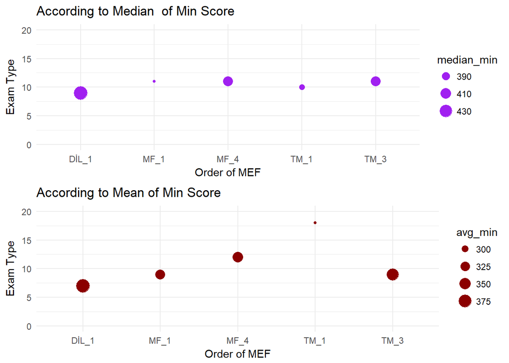

```r
g_median <- ggplot(plot_median,aes(x=exam_type,y=order_of_mef,size=median_min))+
  geom_point(stat="identity",color="purple") + scale_y_continuous(limits = c(0,20)) + xlab("Order of MEF") + ylab("Exam Type") +
  ggtitle("According to Median  of Min Score") +
  theme_minimal()


g_mean <- ggplot(plot_mean,aes(x=exam_type,y=order_of_mef,size=avg_min))+
  geom_point(stat="identity",color="darkred") +  scale_y_continuous(limits = c(0,20)) + xlab("Order of MEF") + ylab("Exam Type") +
  ggtitle("According to Mean of Min Score ") +
  theme_minimal()

grid.arrange(g_median,g_mean,ncol=1)
```

- So, we can easily said that MEF University is on Top 20 List based on all exam types. According to average of min score of all programmes, Exam type:DIL-1 has MEF Uni.’s most preferable programmes. So; university should focus on these programmes if the aim is to be winner on an exam type. On the other hand; Exam type: TM-1 has the worst order, it means programmes of TM-1 are not popular options for students, ergo; MEF Uni. should focus on these programmes on advertising strategy and introducing days of university.

#### 2. Looking At Programmes of MEF University

- Looking at programmes is important when MEF University wants to know their strongest program on market. So firstly; find the top 10 program at MEF University according to max_score.

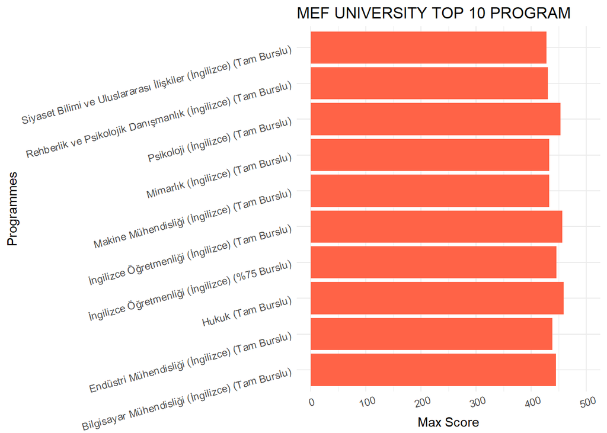

```r
osym_data_2017<-osym
ist.uni<-osym_data_2017 %>% filter(grepl("STANBUL",city))
mef.uni<-ist.uni %>% filter(grepl("MEF",university_name))
mef.uni.top_10 <- mef.uni %>% group_by(program_name) %>% summarise(max_max_score=max(max_score)) %>% top_n(10)
ggplot(mef.uni.top_10,aes(x=program_name,y=max_max_score)) + geom_bar(stat="identity",fill="tomato",width = 0.9) +scale_y_continuous(limits = c(0,500))+
  theme_minimal() +  coord_flip() +theme(axis.text = element_text(angle = 15)) + xlab("Programmes") + ylab("Max Score") + ggtitle("MEF UNIVERSITY TOP 10 PROGRAM")
```

- According to graph; it can be observed programmes with OSYM scholarship is the most popular programmes, especially if it is full scholarship. So; MEF University can expand scholarship quota of top 10 programmes to gain more student and take advantage on undergraduate market.
- Another valuable point from graph is that “Hukuk (Tam Burslu)” program of MEF University has the max score on exam. We should glance at other universities which has “Hukuk (Tam Burslu)” program to check which of them are MEF University’s competitors on this program in the undergraduate market.

```r
ist.uni.hukuk <- ist.uni %>% filter(program_name=="Hukuk (Tam Burslu)")
orderedhukuk<-ist.uni.hukuk%>%arrange(desc(max_score))
orderedhukuk%>%select(university_name,max_score)
```

```
## # A tibble: 20 x 2
##                           university_name max_score
##                                     <chr>     <dbl>
##  1                       KOÇ ÜNIVERSITESI  558.3680
##  2                   ÖZYEGIN ÜNIVERSITESI  522.6578
##  3                  YEDITEPE ÜNIVERSITESI  521.7373
##  4                BAHÇESEHIR ÜNIVERSITESI  519.3311
##  5            ISTANBUL SEHIR ÜNIVERSITESI  509.7540
##  6            ISTANBUL BILGI ÜNIVERSITESI  495.1883
##  7           ISTANBUL KÜLTÜR ÜNIVERSITESI  485.4321
##  8  ISTANBUL SABAHATTIN ZAIM ÜNIVERSITESI  478.2252
##  9                IBN HALDUN ÜNIVERSITESI  474.7438
## 10 FATIH SULTAN MEHMET VAKIF ÜNIVERSITESI  462.3083
## 11                 KADIR HAS ÜNIVERSITESI  461.4800
## 12                       MEF ÜNIVERSITESI  459.0143
## 13                      OKAN ÜNIVERSITESI  441.8761
## 14          ISTANBUL MEDIPOL ÜNIVERSITESI  438.8691
## 15          ISTANBUL TICARET ÜNIVERSITESI  434.0833
## 16            ISTANBUL AYDIN ÜNIVERSITESI  433.5820
## 17                  ALTINBAS ÜNIVERSITESI  430.0767
## 18                   MALTEPE ÜNIVERSITESI  430.0614
## 19      ISTANBUL YENI YÜZYIL ÜNIVERSITESI  428.8982
## 20                     DOGUS ÜNIVERSITESI  428.1987
```

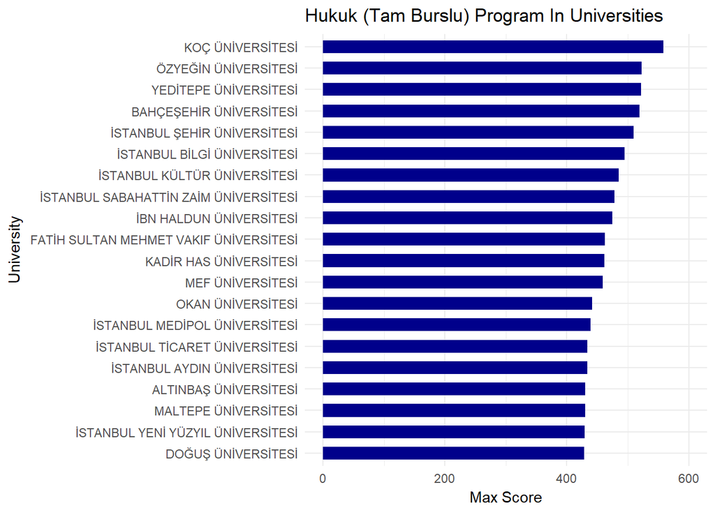

```r
#Graph is better.
set.seed(2)
ggplot(orderedhukuk,aes(x=reorder(university_name,max_score),y=max_score,label=max_score)) + geom_bar(stat="identity",fill="darkblue",width = 0.6)  +  coord_flip() + theme_minimal()   +  scale_y_continuous(limits = c(0,600)) + xlab("University") + ylab("Max Score") + ggtitle("Hukuk (Tam Burslu) Program In Universities")
```

- According to graph; MEF University has strong competitors on “Hukuk (Tam Burslu)” program while it is on top 20 List of this program. Even if it seems hard to be the most preferable university briefly, MEF University should focus on “Hukuk (Tam Burslu)” program on advertising strategy and introducing days of university to ranking up and take advantage on the undergraudate market.